# FigureYa279panGeneGSEA

**Author(s)**: Xiaofan Lu; Yasi Zhang  
**Reviewer(s)**: Ying Ge  
**Date**: 2025-05-20

# 需求描述

# Demand description

想把FigureYa253panGSEAhttps://k.youshop10.com/QbM6nwGB中的单基因多通路的泛癌富集分析改成”多基因，单通路的泛癌富集分析”，即把下图中的Y轴变成了基因，X轴还是癌种。

I want to modify the pan-cancer enrichment analysis in FigureYa253panGSEAhttps://k.youshop10.com/QbM6nwGB from “single-gene multi-pathway” to “multi-gene single-pathway” analysis. That is, changing the Y-axis in the figure to show genes while keeping the X-axis as cancer types.

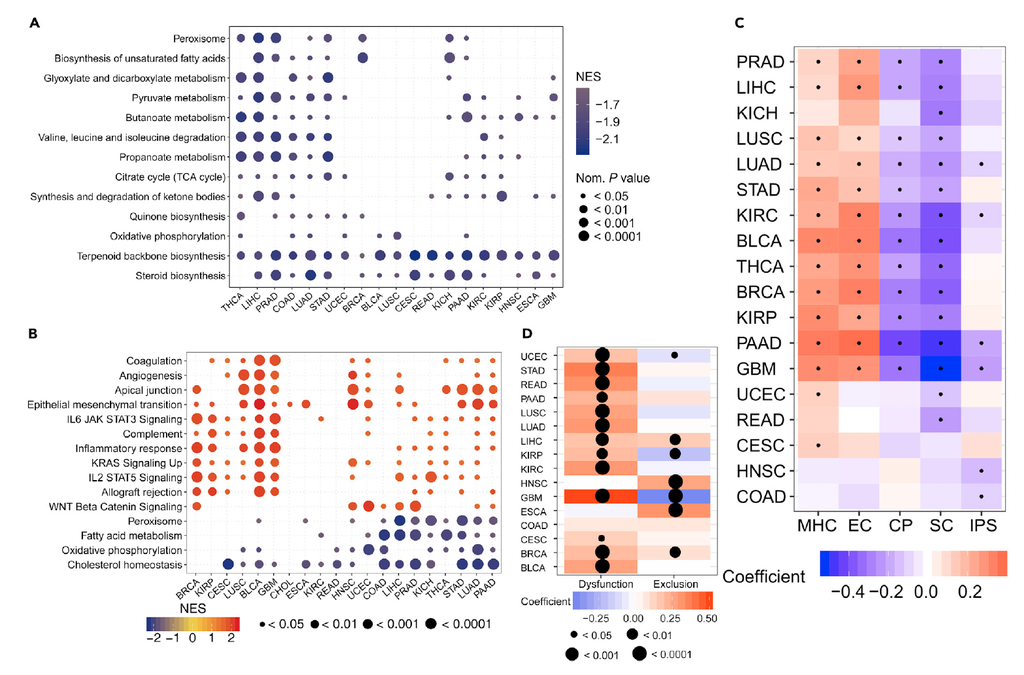

出自：https://www.cell.com/iscience/fulltext/S2589-0042(20)30489-2?_returnURL=https%3A%2F%2Flinkinghub.elsevier.com%2Fretrieve%2Fpii%2FS2589004220304892%3Fshowall%3Dtrue

图3. 铁死亡与信号通路及免疫表型的关系。 (A和B) 高FPI与低FPI肿瘤组织间代谢通路(A)和癌症信号(B)的富集分析。NES表示GSEA算法中的标准化富集分数。

Source: https://www.cell.com/iscience/fulltext/S2589-0042(20)30489-2?_returnURL=https%3A%2F%2Flinkinghub.elsevier.com%2Fretrieve%2Fpii%2FS2589004220304892%3Fshowall%3Dtrue

Figure 3. Relationships between Ferroptosis and Signaling Pathways and Immunophenotypes. (A and B) Enrichment analysis for metabolism pathway (A) and cancer signaling (B) between high- and low-FPI tumor tissues. NES is the normalized enrichment score in the GSEA algorithm.

# 应用场景

# Application scenarios

基于特定基因两组数据，对每个肿瘤进行单基因集富集分析(GSEA)，展示某特定通路的富集情况。

更多pancancer分析画图FigureYa看这里https://k.youshop10.com/C8RkTgR3

Based on two groups of specific gene data, single gene set enrichment analysis (GSEA) was performed for each tumor to demonstrate the enrichment of a particular pathway.

For more pan-cancer analysis and visualization (FigureYa), check herehttps://k.youshop10.com/C8RkTgR3

# 环境设置

# Environment Setup

使用国内镜像安装包。

Using domestic mirrors for package installation.

```r
options("repos"= c(CRAN="https://mirrors.tuna.tsinghua.edu.cn/CRAN/"))
options(BioC_mirror="http://mirrors.tuna.tsinghua.edu.cn/bioconductor/")
```

# 加载包

# Loading packages

```r
library(clusterProfiler)
```

```r
library(limma)
library(ggplot2)
library(data.table)
library(ggpubr)
library(SimDesign)
source("twoclasslimma.R")

# 显示英文报错信息
# Show English error messages
Sys.setenv(LANGUAGE = "en")

# 禁止chr转成factor
# Prevent character-to-factor conversion
options(stringsAsFactors = FALSE)
```

# 输入文件

# Input Files

merged_sample_quality_annotations.tsv，样本分组信息。下载自http://api.gdc.cancer.gov/data/1a7d7be8-675d-4e60-a105-19d4121bdebf。

EBPlusPlusAdjustPANCAN_IlluminaHiSeq_RNASeqV2.geneExp.tsv，表达矩阵，第一列是基因，之后是其在每个样本中的表达量。下载自http://api.gdc.cancer.gov/data/3586c0da-64d0-4b74-a449-5ff4d9136611。

merged_sample_quality_annotations.tsv, sample grouping information. Downloaded from http://api.gdc.cancer.gov/data/1a7d7be8-675d-4e60-a105-19d4121bdebf.

EBPlusPlusAdjustPANCAN_IlluminaHiSeq_RNASeqV2.geneExp.tsv, expression matrix where the first column lists genes, followed by their expression levels in each sample. Downloaded from http://api.gdc.cancer.gov/data/3586c0da-64d0-4b74-a449-5ff4d9136611.

```r
# 生成文件夹来保存中间结果
# Create directory to store intermediate results
res.path <- file.path("Results")
if (!file.exists(res.path)) { dir.create(res.path) }

# 设置颜色
# Define color palette
darkblue <- "#303B7F"
darkred <- "#D51113"
yellow <- "#EECA1F"

# 获取感兴趣的肿瘤类型（有正常和肿瘤样本）
# Select tumor types of interest (with both normal and tumor samples)
tumors <- c("BLCA","BRCA","CESC","CHOL","COAD",
            "ESCA","GBM","HNSC","KICH","KIRC",
            "KIRP","LIHC","LUAD","LUSC","PAAD",
            "PRAD","READ","STAD","THCA","UCEC")

# 从原文中获取感兴趣的基因集 (TTC35/EMC2)
# Extract gene set of interest (TTC35/EMC2) from original publication
genelist <- c("CDKN1A","HSPA5","TTC35","SLC7A11","NFE2L2","MT1G","HSPB1","GPX4","FANCD2","CISD1","FDFT1","SLC1A5","SAT1",
         "TFRC","RPL8","NCOA4","LPCAT3","GLS2","DPP4","CS","CARS","ATP5G3","ALOX15","ACSL4")

# 读取肿瘤注释文件
# Load tumor annotation file
rawAnno <- read.delim("merged_sample_quality_annotations.tsv",sep = "\t",row.names = NULL,check.names = F,stringsAsFactors = F,header = T)
# 数据来自：http://api.gdc.cancer.gov/data/1a7d7be8-675d-4e60-a105-19d4121bdebf
# Data source: http://api.gdc.cancer.gov/data/1a7d7be8-675d-4e60-a105-19d4121bdebf

# 提取简化的样本条形码（前15位字符）
# Extract simplified barcode (first 15 characters)
rawAnno$simple_barcode <- substr(rawAnno$aliquot_barcode,1,15)

# 去重处理并保留关键列
# Remove duplicates and keep essential columns
samAnno <- rawAnno[!duplicated(rawAnno$simple_barcode),c("cancer type", "simple_barcode")]
samAnno <- samAnno[which(samAnno$`cancer type` != ""),]

# 保存处理后的注释文件
# Save processed annotation file
write.table(samAnno,"simple_sample_annotation.txt",sep = "\t",row.names = F,col.names = T,quote = F)

# 快速读取表达谱数据并做数据预处理
# Rapidly load expression matrix and perform preprocessing
expr <- fread("EBPlusPlusAdjustPANCAN_IlluminaHiSeq_RNASeqV2.geneExp.tsv",sep = "\t",stringsAsFactors = F,check.names = F,header = T)
# 数据来自：http://api.gdc.cancer.gov/data/3586c0da-64d0-4b74-a449-5ff4d9136611
# Data source: http://api.gdc.cancer.gov/data/1a7d7be8-675d-4e60-a105-19d4121bdebf

# 转换为数据框格式并处理基因名
# Convert to dataframe and process gene names
expr <- as.data.frame(expr); rownames(expr) <- expr[,1]; expr <- expr[,-1]

# 提取竖线分隔符前的正式基因名
# Extract official gene names before "|" separator
gene <- sapply(strsplit(rownames(expr),"|",fixed = T), "[",1)
expr$gene <- gene

# 去重处理（保留每个基因第一个出现的数据）
# Remove duplicate genes (keep first occurrence)
expr <- expr[!duplicated(expr$gene),]
rownames(expr) <- expr$gene; expr <- expr[,-ncol(expr)]

# 对于这份泛癌数据，将略小于0的数值拉到0，否则不能取log（其他途径下载的泛癌数据可能不需要此操作）
# For this pan-cancer dataset, adjust slightly negative values to 0 to enable log transformation (may not be needed for other pan-cancer datasets)
expr[expr < 0] <- 0

# 简化样本ID（取前15位字符）
# Simplify sample IDs (first 15 characters)
colnames(expr) <- substr(colnames(expr),1,15)

# 内存清理
# Memory cleanup
gc()
```

```
##             used   (Mb) gc trigger   (Mb)  max used   (Mb)
## Ncells   5482761  292.9    9738875  520.2   7696617  411.1
## Vcells 237848161 1814.7  773747813 5903.3 773740938 5903.2
```

# 运行GSEA

# Perform GSEA analysis

```r
# 这里使用的是HALLMARK背景集，可以改为自己感兴趣的基因集合
# Using HALLMARK gene set (can be replaced with custom gene sets of interest)
msigdb.hallmark <- read.gmt("h.all.v7.2.symbols.gmt")

# 30%阈值来定义高低组
# 30% threshold for defining high/low expression groups
pct <- 0.3

# 初始化结果存储表
# Initialize result container
gseaTab <- NULL

# 主分析循环
# Main Analysis Loop
for (i in tumors) {
  message("--",i,"...")

  # 获取当前癌型的样本列表
  # Get samples for current cancer type
  sam <- samAnno[which(samAnno$`cancer type` == i),"simple_barcode"]

  # 得到特定肿瘤类型的表达谱
  # Get expression matrix for specific cancer type
  comsam <- intersect(colnames(expr), sam)

  # 仅提取肿瘤样本
  # Extract tumor samples only
  tumsam <- comsam[substr(comsam,14,14) == "0"]

  # 提取目标基因表达矩阵
  # Subset target gene expression matrix
  es <- expr[genelist,tumsam]

  # 基因级别分析
  # Per-gene Analysis
  for (j in genelist) {
    message("gene of ", j, " starts...")

    # 转置表达矩阵便于排序
    # Transpose matrix for sorting
    es_subset <- as.data.frame(t(es[j,tumsam]))

    # 对表达值排序
    # Sort by expression value
    es_subset <- es_subset[order(es_subset[,1],decreasing = T),,drop = F]

    # 取前30%为高组，取后30%为低组
    # Define high/low expression groups (top/bottom 30%)
    high.es <- rownames(es_subset[1:(nrow(es_subset) * pct),,drop = F])
    low.es <- rownames(es_subset[nrow(es_subset):(nrow(es_subset) - nrow(es_subset) * pct + 1),,drop = F])

    # 创建分组信息表
    # Create sample grouping information
    subt <- data.frame(condition = rep(c("high","low"),c(length(high.es),length(low.es))),
                       row.names = c(high.es, low.es),
                       stringsAsFactors = F)

    # 数据预处理：log2转换（加1伪计数避免零值）
    # Data preprocessing: log2 transformation (with pseudocount)
    gset <- log2(na.omit(expr[,rownames(subt)]) + 1)

    # 执行limma差异分析
    # Perform limma differential analysis
    twoclasslimma(subtype  = subt,
                  featmat  = gset,
                  treatVar = "high",
                  ctrlVar  = "low",
                  prefix   = paste0("TCGA_",i,"_",j),
                  overwt   = T,
                  sort.p   = F,
                  verbose  = TRUE,
                  res.path = res.path)

    # 加载差异表达结果
    # Load differential expression results
    res <- read.table(file.path(res.path, paste0("TCGA_",i,"_",j,"_limma_test_result.high_vs_low.txt")),sep = "\t",row.names = 1,check.names = F,stringsAsFactors = F,header = T)

    # 产生pre-ranked基因列表
    # Generate a pre-ranked list of genes
    res <- res[order(res$log2fc, decreasing = T),]
    glist <- res$log2fc; names(glist) <- rownames(res)

    # 运行GSEA
    # Run GSEA analysis
    set.seed(20220407)
    gsea <- quiet(GSEA(geneList = glist,
                 pvalueCutoff = 1,
                 seed = TRUE,
                 TERM2GENE = msigdb.hallmark,
                 verbose = TRUE))

    # 内存清理
    # Memory cleanup
    gc()

    # 转换GSEA结果为数据框
    # Convert GSEA result to dataframe
    gsea.df <- as.data.frame(gsea)

    # 保存当前基因的GSEA结果
    # Save per-gene GSEA results
    write.table(gsea.df,file = file.path(res.path,paste0("gsea between high and low group of gene ",j," in ",i,".txt")),sep = "\t",row.names = T,col.names = NA,quote = F)

    # 合并结果到总表
    # Aggregate results to master table
    gseaTab <- rbind.data.frame(gseaTab,
                                data.frame(tumor = i,
                                           gene = j,
                                           term = gsea.df$ID,
                                           NES = gsea.df$NES,
                                           pval = gsea.df$pvalue,
                                           FDR = gsea.df$p.adjust,
                                           stringsAsFactors = F),
                                stringsAsFactors = F)
  }
}
```

```
## --BLCA...
```

```
## gene of CDKN1A starts...
```

[output not shown]

```
## limma of high_vs_low done...
```

[output not shown]

```
## limma of high_vs_low done...
```

[output not shown]

```
## limma of high_vs_low done...
```

[output not shown]

```
## limma of high_vs_low done...
```

```
## gene of NFE2L2 starts...
## --feature matrix seems to have been standardised (z-score or log transformation), no more action will be performed.
```

```
## limma of high_vs_low done...
```

```
## gene of MT1G starts...
## --feature matrix seems to have been standardised (z-score or log transformation), no more action will be performed.
```

```
## limma of high_vs_low done...
```

```
## gene of HSPB1 starts...
## --feature matrix seems to have been standardised (z-score or log transformation), no more action will be performed.
```

```
## limma of high_vs_low done...
```

```
## gene of GPX4 starts...
## --feature matrix seems to have been standardised (z-score or log transformation), no more action will be performed.
```

```
## limma of high_vs_low done...
```

```
## gene of FANCD2 starts...
## --feature matrix seems to have been standardised (z-score or log transformation), no more action will be performed.
```

```
## limma of high_vs_low done...
```

```
## gene of CISD1 starts...
## --feature matrix seems to have been standardised (z-score or log transformation), no more action will be performed.
```

```
## limma of high_vs_low done...
```

```
## gene of FDFT1 starts...
## --feature matrix seems to have been standardised (z-score or log transformation), no more action will be performed.
```

```
## limma of high_vs_low done...
```

```
## gene of SLC1A5 starts...
## --feature matrix seems to have been standardised (z-score or log transformation), no more action will be performed.
```

```
## limma of high_vs_low done...
```

```
## gene of SAT1 starts...
## --feature matrix seems to have been standardised (z-score or log transformation), no more action will be performed.
```

```
## limma of high_vs_low done...
```

```
## gene of TFRC starts...
## --feature matrix seems to have been standardised (z-score or log transformation), no more action will be performed.
```

```
## limma of high_vs_low done...
```

```
## gene of RPL8 starts...
## --feature matrix seems to have been standardised (z-score or log transformation), no more action will be performed.
```

```
## limma of high_vs_low done...
```

```
## gene of NCOA4 starts...
## --feature matrix seems to have been standardised (z-score or log transformation), no more action will be performed.
```

```
## limma of high_vs_low done...
```

```
## gene of LPCAT3 starts...
## --feature matrix seems to have been standardised (z-score or log transformation), no more action will be performed.
```

```
## limma of high_vs_low done...
```

```
## gene of GLS2 starts...
## --feature matrix seems to have been standardised (z-score or log transformation), no more action will be performed.
```

```
## limma of high_vs_low done...
```

```
## gene of DPP4 starts...
## --feature matrix seems to have been standardised (z-score or log transformation), no more action will be performed.
```

```
## limma of high_vs_low done...
```

```
## gene of CS starts...
## --feature matrix seems to have been standardised (z-score or log transformation), no more action will be performed.
```

```
## limma of high_vs_low done...
```

```
## gene of CARS starts...
## --feature matrix seems to have been standardised (z-score or log transformation), no more action will be performed.
```

```
## limma of high_vs_low done...
```

```
## gene of ATP5G3 starts...
## --feature matrix seems to have been standardised (z-score or log transformation), no more action will be performed.
```

```
## limma of high_vs_low done...
```

```
## gene of ALOX15 starts...
## --feature matrix seems to have been standardised (z-score or log transformation), no more action will be performed.
```

```
## limma of high_vs_low done...
```

```
## gene of ACSL4 starts...
## --feature matrix seems to have been standardised (z-score or log transformation), no more action will be performed.
```

```
## limma of high_vs_low done...
```

```
## --BRCA...
```

```
## gene of CDKN1A starts...
```

[output not shown]

```
## limma of high_vs_low done...
```

[output not shown]

```
## limma of high_vs_low done...
```

```
## gene of TTC35 starts...
## --feature matrix seems to have been standardised (z-score or log transformation), no more action will be performed.
```

```
## limma of high_vs_low done...
```

```
## gene of SLC7A11 starts...
## --feature matrix seems to have been standardised (z-score or log transformation), no more action will be performed.
```

```
## limma of high_vs_low done...
```

```
## gene of NFE2L2 starts...
## --feature matrix seems to have been standardised (z-score or log transformation), no more action will be performed.
```

```
## limma of high_vs_low done...
```

```
## gene of MT1G starts...
## --feature matrix seems to have been standardised (z-score or log transformation), no more action will be performed.
```

```
## limma of high_vs_low done...
```

```
## gene of HSPB1 starts...
## --feature matrix seems to have been standardised (z-score or log transformation), no more action will be performed.
```

```
## limma of high_vs_low done...
```

```
## gene of GPX4 starts...
## --feature matrix seems to have been standardised (z-score or log transformation), no more action will be performed.
```

```
## limma of high_vs_low done...
```

```
## gene of FANCD2 starts...
## --feature matrix seems to have been standardised (z-score or log transformation), no more action will be performed.
```

```
## limma of high_vs_low done...
```

```
## gene of CISD1 starts...
## --feature matrix seems to have been standardised (z-score or log transformation), no more action will be performed.
```

```
## limma of high_vs_low done...
```

```
## gene of FDFT1 starts...
## --feature matrix seems to have been standardised (z-score or log transformation), no more action will be performed.
```

```
## limma of high_vs_low done...
```

```
## gene of SLC1A5 starts...
## --feature matrix seems to have been standardised (z-score or log transformation), no more action will be performed.
```

```
## limma of high_vs_low done...
```

```
## gene of SAT1 starts...
## --feature matrix seems to have been standardised (z-score or log transformation), no more action will be performed.
```

```
## limma of high_vs_low done...
```

```
## gene of TFRC starts...
## --feature matrix seems to have been standardised (z-score or log transformation), no more action will be performed.
```

```
## limma of high_vs_low done...
```

```
## gene of RPL8 starts...
## --feature matrix seems to have been standardised (z-score or log transformation), no more action will be performed.
```

```
## limma of high_vs_low done...
```

```
## gene of NCOA4 starts...
## --feature matrix seems to have been standardised (z-score or log transformation), no more action will be performed.
```

```
## limma of high_vs_low done...
```

```
## gene of LPCAT3 starts...
## --feature matrix seems to have been standardised (z-score or log transformation), no more action will be performed.
```

```
## limma of high_vs_low done...
```

```
## gene of GLS2 starts...
## --feature matrix seems to have been standardised (z-score or log transformation), no more action will be performed.
```

```
## limma of high_vs_low done...
```

```
## gene of DPP4 starts...
## --feature matrix seems to have been standardised (z-score or log transformation), no more action will be performed.
```

```
## limma of high_vs_low done...
```

```
## gene of CS starts...
## --feature matrix seems to have been standardised (z-score or log transformation), no more action will be performed.
```

```
## limma of high_vs_low done...
```

```
## gene of CARS starts...
## --feature matrix seems to have been standardised (z-score or log transformation), no more action will be performed.
```

```
## limma of high_vs_low done...
```

```
## gene of ATP5G3 starts...
## --feature matrix seems to have been standardised (z-score or log transformation), no more action will be performed.
```

```
## limma of high_vs_low done...
```

```
## gene of ALOX15 starts...
## --feature matrix seems to have been standardised (z-score or log transformation), no more action will be performed.
```

```
## limma of high_vs_low done...
```

```
## gene of ACSL4 starts...
## --feature matrix seems to have been standardised (z-score or log transformation), no more action will be performed.
```

```
## limma of high_vs_low done...
```

```
## --CESC...
```

```
## gene of CDKN1A starts...
```

[output not shown]

```
## limma of high_vs_low done...
```

[output not shown]

```
## limma of high_vs_low done...
```

```
## gene of TTC35 starts...
## --feature matrix seems to have been standardised (z-score or log transformation), no more action will be performed.
```

```
## limma of high_vs_low done...
```

```
## gene of SLC7A11 starts...
## --feature matrix seems to have been standardised (z-score or log transformation), no more action will be performed.
```

```
## limma of high_vs_low done...
```

```
## gene of NFE2L2 starts...
## --feature matrix seems to have been standardised (z-score or log transformation), no more action will be performed.
```

```
## limma of high_vs_low done...
```

```
## gene of MT1G starts...
## --feature matrix seems to have been standardised (z-score or log transformation), no more action will be performed.
```

```
## limma of high_vs_low done...
```

```
## gene of HSPB1 starts...
## --feature matrix seems to have been standardised (z-score or log transformation), no more action will be performed.
```

```
## limma of high_vs_low done...
```

```
## gene of GPX4 starts...
## --feature matrix seems to have been standardised (z-score or log transformation), no more action will be performed.
```

```
## limma of high_vs_low done...
```

```
## gene of FANCD2 starts...
## --feature matrix seems to have been standardised (z-score or log transformation), no more action will be performed.
```

```
## limma of high_vs_low done...
```

```
## gene of CISD1 starts...
## --feature matrix seems to have been standardised (z-score or log transformation), no more action will be performed.
```

```
## limma of high_vs_low done...
```

```
## gene of FDFT1 starts...
## --feature matrix seems to have been standardised (z-score or log transformation), no more action will be performed.
```

```
## limma of high_vs_low done...
```

```
## gene of SLC1A5 starts...
## --feature matrix seems to have been standardised (z-score or log transformation), no more action will be performed.
```

```
## limma of high_vs_low done...
```

```
## gene of SAT1 starts...
## --feature matrix seems to have been standardised (z-score or log transformation), no more action will be performed.
```

```
## limma of high_vs_low done...
```

```
## gene of TFRC starts...
## --feature matrix seems to have been standardised (z-score or log transformation), no more action will be performed.
```

```
## limma of high_vs_low done...
```

```
## gene of RPL8 starts...
## --feature matrix seems to have been standardised (z-score or log transformation), no more action will be performed.
```

```
## limma of high_vs_low done...
```

```
## gene of NCOA4 starts...
## --feature matrix seems to have been standardised (z-score or log transformation), no more action will be performed.
```

```
## limma of high_vs_low done...
```

```
## gene of LPCAT3 starts...
## --feature matrix seems to have been standardised (z-score or log transformation), no more action will be performed.
```

```
## limma of high_vs_low done...
```

```
## gene of GLS2 starts...
## --feature matrix seems to have been standardised (z-score or log transformation), no more action will be performed.
```

```
## limma of high_vs_low done...
```

```
## gene of DPP4 starts...
## --feature matrix seems to have been standardised (z-score or log transformation), no more action will be performed.
```

```
## limma of high_vs_low done...
```

```
## gene of CS starts...
## --feature matrix seems to have been standardised (z-score or log transformation), no more action will be performed.
```

```
## limma of high_vs_low done...
```

```
## gene of CARS starts...
## --feature matrix seems to have been standardised (z-score or log transformation), no more action will be performed.
```

```
## limma of high_vs_low done...
```

```
## gene of ATP5G3 starts...
## --feature matrix seems to have been standardised (z-score or log transformation), no more action will be performed.
```

```
## limma of high_vs_low done...
```

```
## gene of ALOX15 starts...
## --feature matrix seems to have been standardised (z-score or log transformation), no more action will be performed.
```

```
## limma of high_vs_low done...
```

```
## gene of ACSL4 starts...
## --feature matrix seems to have been standardised (z-score or log transformation), no more action will be performed.
```

```
## limma of high_vs_low done...
```

```
## --CHOL...
```

```
## gene of CDKN1A starts...
```

[output not shown]

```
## limma of high_vs_low done...
```

[output not shown]

```
## limma of high_vs_low done...
```

```
## gene of TTC35 starts...
## --feature matrix seems to have been standardised (z-score or log transformation), no more action will be performed.
```

```
## limma of high_vs_low done...
```

```
## gene of SLC7A11 starts...
## --feature matrix seems to have been standardised (z-score or log transformation), no more action will be performed.
```

```
## limma of high_vs_low done...
```

```
## gene of NFE2L2 starts...
## --feature matrix seems to have been standardised (z-score or log transformation), no more action will be performed.
```

```
## limma of high_vs_low done...
```

```
## gene of MT1G starts...
## --feature matrix seems to have been standardised (z-score or log transformation), no more action will be performed.
```

```
## limma of high_vs_low done...
```

```
## gene of HSPB1 starts...
## --feature matrix seems to have been standardised (z-score or log transformation), no more action will be performed.
```

```
## limma of high_vs_low done...
```

```
## gene of GPX4 starts...
## --feature matrix seems to have been standardised (z-score or log transformation), no more action will be performed.
```

```
## limma of high_vs_low done...
```

```
## gene of FANCD2 starts...
## --feature matrix seems to have been standardised (z-score or log transformation), no more action will be performed.
```

```
## limma of high_vs_low done...
```

```
## gene of CISD1 starts...
## --feature matrix seems to have been standardised (z-score or log transformation), no more action will be performed.
```

```
## limma of high_vs_low done...
```

```
## gene of FDFT1 starts...
## --feature matrix seems to have been standardised (z-score or log transformation), no more action will be performed.
```

```
## limma of high_vs_low done...
```

```
## gene of SLC1A5 starts...
## --feature matrix seems to have been standardised (z-score or log transformation), no more action will be performed.
```

```
## limma of high_vs_low done...
```

```
## gene of SAT1 starts...
## --feature matrix seems to have been standardised (z-score or log transformation), no more action will be performed.
```

```
## limma of high_vs_low done...
```

```
## gene of TFRC starts...
## --feature matrix seems to have been standardised (z-score or log transformation), no more action will be performed.
```

```
## limma of high_vs_low done...
```

```
## gene of RPL8 starts...
## --feature matrix seems to have been standardised (z-score or log transformation), no more action will be performed.
```

```
## limma of high_vs_low done...
```

```
## gene of NCOA4 starts...
## --feature matrix seems to have been standardised (z-score or log transformation), no more action will be performed.
```

```
## limma of high_vs_low done...
```

```
## gene of LPCAT3 starts...
## --feature matrix seems to have been standardised (z-score or log transformation), no more action will be performed.
```

```
## limma of high_vs_low done...
```

```
## gene of GLS2 starts...
## --feature matrix seems to have been standardised (z-score or log transformation), no more action will be performed.
```

```
## limma of high_vs_low done...
```

```
## gene of DPP4 starts...
## --feature matrix seems to have been standardised (z-score or log transformation), no more action will be performed.
```

```
## limma of high_vs_low done...
```

```
## gene of CS starts...
## --feature matrix seems to have been standardised (z-score or log transformation), no more action will be performed.
```

```
## limma of high_vs_low done...
```

```
## gene of CARS starts...
## --feature matrix seems to have been standardised (z-score or log transformation), no more action will be performed.
```

```
## limma of high_vs_low done...
```

```
## gene of ATP5G3 starts...
## --feature matrix seems to have been standardised (z-score or log transformation), no more action will be performed.
```

```
## limma of high_vs_low done...
```

```
## gene of ALOX15 starts...
## --feature matrix seems to have been standardised (z-score or log transformation), no more action will be performed.
```

```
## limma of high_vs_low done...
```

```
## gene of ACSL4 starts...
## --feature matrix seems to have been standardised (z-score or log transformation), no more action will be performed.
```

```
## limma of high_vs_low done...
```

```
## --COAD...
```

```
## gene of CDKN1A starts...
```

[output not shown]

```
## limma of high_vs_low done...
```

[output not shown]

```
## limma of high_vs_low done...
```

```
## gene of TTC35 starts...
## --feature matrix seems to have been standardised (z-score or log transformation), no more action will be performed.
```

```
## limma of high_vs_low done...
```

```
## gene of SLC7A11 starts...
## --feature matrix seems to have been standardised (z-score or log transformation), no more action will be performed.
```

```
## limma of high_vs_low done...
```

```
## gene of NFE2L2 starts...
## --feature matrix seems to have been standardised (z-score or log transformation), no more action will be performed.
```

```
## limma of high_vs_low done...
```

```
## gene of MT1G starts...
## --feature matrix seems to have been standardised (z-score or log transformation), no more action will be performed.
```

```
## limma of high_vs_low done...
```

```
## gene of HSPB1 starts...
## --feature matrix seems to have been standardised (z-score or log transformation), no more action will be performed.
```

```
## limma of high_vs_low done...
```

```
## gene of GPX4 starts...
## --feature matrix seems to have been standardised (z-score or log transformation), no more action will be performed.
```

```
## limma of high_vs_low done...
```

```
## gene of FANCD2 starts...
## --feature matrix seems to have been standardised (z-score or log transformation), no more action will be performed.
```

```
## limma of high_vs_low done...
```

```
## gene of CISD1 starts...
## --feature matrix seems to have been standardised (z-score or log transformation), no more action will be performed.
```

```
## limma of high_vs_low done...
```

```
## gene of FDFT1 starts...
## --feature matrix seems to have been standardised (z-score or log transformation), no more action will be performed.
```

```
## limma of high_vs_low done...
```

```
## gene of SLC1A5 starts...
## --feature matrix seems to have been standardised (z-score or log transformation), no more action will be performed.
```

```
## limma of high_vs_low done...
```

```
## gene of SAT1 starts...
## --feature matrix seems to have been standardised (z-score or log transformation), no more action will be performed.
```

```
## limma of high_vs_low done...
```

```
## gene of TFRC starts...
## --feature matrix seems to have been standardised (z-score or log transformation), no more action will be performed.
```

```
## limma of high_vs_low done...
```

```
## gene of RPL8 starts...
## --feature matrix seems to have been standardised (z-score or log transformation), no more action will be performed.
```

```
## limma of high_vs_low done...
```

```
## gene of NCOA4 starts...
## --feature matrix seems to have been standardised (z-score or log transformation), no more action will be performed.
```

```
## limma of high_vs_low done...
```

```
## gene of LPCAT3 starts...
## --feature matrix seems to have been standardised (z-score or log transformation), no more action will be performed.
```

```
## limma of high_vs_low done...
```

```
## gene of GLS2 starts...
## --feature matrix seems to have been standardised (z-score or log transformation), no more action will be performed.
```

```
## limma of high_vs_low done...
```

```
## gene of DPP4 starts...
## --feature matrix seems to have been standardised (z-score or log transformation), no more action will be performed.
```

```
## limma of high_vs_low done...
```

```
## gene of CS starts...
## --feature matrix seems to have been standardised (z-score or log transformation), no more action will be performed.
```

```
## limma of high_vs_low done...
```

```
## gene of CARS starts...
## --feature matrix seems to have been standardised (z-score or log transformation), no more action will be performed.
```

```
## limma of high_vs_low done...
```

```
## gene of ATP5G3 starts...
## --feature matrix seems to have been standardised (z-score or log transformation), no more action will be performed.
```

```
## limma of high_vs_low done...
```

```
## gene of ALOX15 starts...
## --feature matrix seems to have been standardised (z-score or log transformation), no more action will be performed.
```

```
## limma of high_vs_low done...
```

```
## gene of ACSL4 starts...
## --feature matrix seems to have been standardised (z-score or log transformation), no more action will be performed.
```

```
## limma of high_vs_low done...
```

```
## --ESCA...
```

```
## gene of CDKN1A starts...
```

[output not shown]

```
## limma of high_vs_low done...
```

```
## gene of HSPA5 starts...
## --feature matrix seems to have been standardised (z-score or log transformation), no more action will be performed.
```

```
## limma of high_vs_low done...
```

```
## gene of TTC35 starts...
## --feature matrix seems to have been standardised (z-score or log transformation), no more action will be performed.
```

```
## limma of high_vs_low done...
```

```
## gene of SLC7A11 starts...
## --feature matrix seems to have been standardised (z-score or log transformation), no more action will be performed.
```

```
## limma of high_vs_low done...
```

```
## gene of NFE2L2 starts...
## --feature matrix seems to have been standardised (z-score or log transformation), no more action will be performed.
```

```
## limma of high_vs_low done...
```

```
## gene of MT1G starts...
## --feature matrix seems to have been standardised (z-score or log transformation), no more action will be performed.
```

```
## limma of high_vs_low done...
```

```
## gene of HSPB1 starts...
## --feature matrix seems to have been standardised (z-score or log transformation), no more action will be performed.
```

```
## limma of high_vs_low done...
```

```
## gene of GPX4 starts...
## --feature matrix seems to have been standardised (z-score or log transformation), no more action will be performed.
```

```
## limma of high_vs_low done...
```

```
## gene of FANCD2 starts...
## --feature matrix seems to have been standardised (z-score or log transformation), no more action will be performed.
```

```
## limma of high_vs_low done...
```

```
## gene of CISD1 starts...
## --feature matrix seems to have been standardised (z-score or log transformation), no more action will be performed.
```

```
## limma of high_vs_low done...
```

```
## gene of FDFT1 starts...
## --feature matrix seems to have been standardised (z-score or log transformation), no more action will be performed.
```

```
## limma of high_vs_low done...
```

```
## gene of SLC1A5 starts...
## --feature matrix seems to have been standardised (z-score or log transformation), no more action will be performed.
```

```
## limma of high_vs_low done...
```

```
## gene of SAT1 starts...
## --feature matrix seems to have been standardised (z-score or log transformation), no more action will be performed.
```

```
## limma of high_vs_low done...
```

```
## gene of TFRC starts...
## --feature matrix seems to have been standardised (z-score or log transformation), no more action will be performed.
```

```
## limma of high_vs_low done...
```

```
## gene of RPL8 starts...
## --feature matrix seems to have been standardised (z-score or log transformation), no more action will be performed.
```

```
## limma of high_vs_low done...
```

```
## gene of NCOA4 starts...
## --feature matrix seems to have been standardised (z-score or log transformation), no more action will be performed.
```

```
## limma of high_vs_low done...
```

```
## gene of LPCAT3 starts...
## --feature matrix seems to have been standardised (z-score or log transformation), no more action will be performed.
```

```
## limma of high_vs_low done...
```

```
## gene of GLS2 starts...
## --feature matrix seems to have been standardised (z-score or log transformation), no more action will be performed.
```

```
## limma of high_vs_low done...
```

```
## gene of DPP4 starts...
## --feature matrix seems to have been standardised (z-score or log transformation), no more action will be performed.
```

```
## limma of high_vs_low done...
```

```
## gene of CS starts...
## --feature matrix seems to have been standardised (z-score or log transformation), no more action will be performed.
```

```
## limma of high_vs_low done...
```

```
## gene of CARS starts...
## --feature matrix seems to have been standardised (z-score or log transformation), no more action will be performed.
```

```
## limma of high_vs_low done...
```

```
## gene of ATP5G3 starts...
## --feature matrix seems to have been standardised (z-score or log transformation), no more action will be performed.
```

```
## limma of high_vs_low done...
```

```
## gene of ALOX15 starts...
## --feature matrix seems to have been standardised (z-score or log transformation), no more action will be performed.
```

```
## limma of high_vs_low done...
```

```
## gene of ACSL4 starts...
## --feature matrix seems to have been standardised (z-score or log transformation), no more action will be performed.
```

```
## limma of high_vs_low done...
```

```
## --GBM...
```

```
## gene of CDKN1A starts...
```

[output not shown]

```
## limma of high_vs_low done...
```

```
## gene of HSPA5 starts...
## --feature matrix seems to have been standardised (z-score or log transformation), no more action will be performed.
```

```
## limma of high_vs_low done...
```

```
## gene of TTC35 starts...
## --feature matrix seems to have been standardised (z-score or log transformation), no more action will be performed.
```

```
## limma of high_vs_low done...
```

```
## gene of SLC7A11 starts...
## --feature matrix seems to have been standardised (z-score or log transformation), no more action will be performed.
```

```
## limma of high_vs_low done...
```

```
## gene of NFE2L2 starts...
## --feature matrix seems to have been standardised (z-score or log transformation), no more action will be performed.
```

```
## limma of high_vs_low done...
```

```
## gene of MT1G starts...
## --feature matrix seems to have been standardised (z-score or log transformation), no more action will be performed.
```

```
## limma of high_vs_low done...
```

```
## gene of HSPB1 starts...
## --feature matrix seems to have been standardised (z-score or log transformation), no more action will be performed.
```

```
## limma of high_vs_low done...
```

```
## gene of GPX4 starts...
## --feature matrix seems to have been standardised (z-score or log transformation), no more action will be performed.
```

```
## limma of high_vs_low done...
```

```
## gene of FANCD2 starts...
## --feature matrix seems to have been standardised (z-score or log transformation), no more action will be performed.
```

```
## limma of high_vs_low done...
```

```
## gene of CISD1 starts...
## --feature matrix seems to have been standardised (z-score or log transformation), no more action will be performed.
```

```
## limma of high_vs_low done...
```

```
## gene of FDFT1 starts...
## --feature matrix seems to have been standardised (z-score or log transformation), no more action will be performed.
```

```
## limma of high_vs_low done...
```

```
## gene of SLC1A5 starts...
## --feature matrix seems to have been standardised (z-score or log transformation), no more action will be performed.
```

```
## limma of high_vs_low done...
```

```
## gene of SAT1 starts...
## --feature matrix seems to have been standardised (z-score or log transformation), no more action will be performed.
```

```
## limma of high_vs_low done...
```

```
## gene of TFRC starts...
## --feature matrix seems to have been standardised (z-score or log transformation), no more action will be performed.
```

```
## limma of high_vs_low done...
```

```
## gene of RPL8 starts...
## --feature matrix seems to have been standardised (z-score or log transformation), no more action will be performed.
```

```
## limma of high_vs_low done...
```

```
## gene of NCOA4 starts...
## --feature matrix seems to have been standardised (z-score or log transformation), no more action will be performed.
```

```
## limma of high_vs_low done...
```

```
## gene of LPCAT3 starts...
## --feature matrix seems to have been standardised (z-score or log transformation), no more action will be performed.
```

```
## limma of high_vs_low done...
```

```
## gene of GLS2 starts...
## --feature matrix seems to have been standardised (z-score or log transformation), no more action will be performed.
```

```
## limma of high_vs_low done...
```

```
## gene of DPP4 starts...
## --feature matrix seems to have been standardised (z-score or log transformation), no more action will be performed.
```

```
## limma of high_vs_low done...
```

```
## gene of CS starts...
## --feature matrix seems to have been standardised (z-score or log transformation), no more action will be performed.
```

```
## limma of high_vs_low done...
```

```
## gene of CARS starts...
## --feature matrix seems to have been standardised (z-score or log transformation), no more action will be performed.
```

```
## limma of high_vs_low done...
```

```
## gene of ATP5G3 starts...
## --feature matrix seems to have been standardised (z-score or log transformation), no more action will be performed.
```

```
## limma of high_vs_low done...
```

```
## gene of ALOX15 starts...
## --feature matrix seems to have been standardised (z-score or log transformation), no more action will be performed.
```

```
## limma of high_vs_low done...
```

```
## gene of ACSL4 starts...
## --feature matrix seems to have been standardised (z-score or log transformation), no more action will be performed.
```

```
## limma of high_vs_low done...
```

```
## --HNSC...
```

```
## gene of CDKN1A starts...
```

[output not shown]

```
## limma of high_vs_low done...
```

```
## gene of HSPA5 starts...
## --feature matrix seems to have been standardised (z-score or log transformation), no more action will be performed.
```

```
## limma of high_vs_low done...
```

```
## gene of TTC35 starts...
## --feature matrix seems to have been standardised (z-score or log transformation), no more action will be performed.
```

```
## limma of high_vs_low done...
```

```
## gene of SLC7A11 starts...
## --feature matrix seems to have been standardised (z-score or log transformation), no more action will be performed.
```

```
## limma of high_vs_low done...
```

```
## gene of NFE2L2 starts...
## --feature matrix seems to have been standardised (z-score or log transformation), no more action will be performed.
```

```
## limma of high_vs_low done...
```

```
## gene of MT1G starts...
## --feature matrix seems to have been standardised (z-score or log transformation), no more action will be performed.
```

```
## limma of high_vs_low done...
```

```
## gene of HSPB1 starts...
## --feature matrix seems to have been standardised (z-score or log transformation), no more action will be performed.
```

```
## limma of high_vs_low done...
```

```
## gene of GPX4 starts...
## --feature matrix seems to have been standardised (z-score or log transformation), no more action will be performed.
```

```
## limma of high_vs_low done...
```

```
## gene of FANCD2 starts...
## --feature matrix seems to have been standardised (z-score or log transformation), no more action will be performed.
```

```
## limma of high_vs_low done...
```

```
## gene of CISD1 starts...
## --feature matrix seems to have been standardised (z-score or log transformation), no more action will be performed.
```

```
## limma of high_vs_low done...
```

```
## gene of FDFT1 starts...
## --feature matrix seems to have been standardised (z-score or log transformation), no more action will be performed.
```

```
## limma of high_vs_low done...
```

```
## gene of SLC1A5 starts...
## --feature matrix seems to have been standardised (z-score or log transformation), no more action will be performed.
```

```
## limma of high_vs_low done...
```

```
## gene of SAT1 starts...
## --feature matrix seems to have been standardised (z-score or log transformation), no more action will be performed.
```

```
## limma of high_vs_low done...
```

```
## gene of TFRC starts...
## --feature matrix seems to have been standardised (z-score or log transformation), no more action will be performed.
```

```
## limma of high_vs_low done...
```

```
## gene of RPL8 starts...
## --feature matrix seems to have been standardised (z-score or log transformation), no more action will be performed.
```

```
## limma of high_vs_low done...
```

```
## gene of NCOA4 starts...
## --feature matrix seems to have been standardised (z-score or log transformation), no more action will be performed.
```

```
## limma of high_vs_low done...
```

```
## gene of LPCAT3 starts...
## --feature matrix seems to have been standardised (z-score or log transformation), no more action will be performed.
```

```
## limma of high_vs_low done...
```

```
## gene of GLS2 starts...
## --feature matrix seems to have been standardised (z-score or log transformation), no more action will be performed.
```

```
## limma of high_vs_low done...
```

```
## gene of DPP4 starts...
## --feature matrix seems to have been standardised (z-score or log transformation), no more action will be performed.
```

```
## limma of high_vs_low done...
```

```
## gene of CS starts...
## --feature matrix seems to have been standardised (z-score or log transformation), no more action will be performed.
```

```
## limma of high_vs_low done...
```

```
## gene of CARS starts...
## --feature matrix seems to have been standardised (z-score or log transformation), no more action will be performed.
```

```
## limma of high_vs_low done...
```

```
## gene of ATP5G3 starts...
## --feature matrix seems to have been standardised (z-score or log transformation), no more action will be performed.
```

```
## limma of high_vs_low done...
```

```
## gene of ALOX15 starts...
## --feature matrix seems to have been standardised (z-score or log transformation), no more action will be performed.
```

```
## limma of high_vs_low done...
```

```
## gene of ACSL4 starts...
## --feature matrix seems to have been standardised (z-score or log transformation), no more action will be performed.
```

```
## limma of high_vs_low done...
```

```
## --KICH...
```

```
## gene of CDKN1A starts...
```

[output not shown]

```
## limma of high_vs_low done...
```

```
## gene of HSPA5 starts...
## --feature matrix seems to have been standardised (z-score or log transformation), no more action will be performed.
```

```
## limma of high_vs_low done...
```

```
## gene of TTC35 starts...
## --feature matrix seems to have been standardised (z-score or log transformation), no more action will be performed.
```

```
## limma of high_vs_low done...
```

```
## gene of SLC7A11 starts...
## --feature matrix seems to have been standardised (z-score or log transformation), no more action will be performed.
```

```
## limma of high_vs_low done...
```

```
## gene of NFE2L2 starts...
## --feature matrix seems to have been standardised (z-score or log transformation), no more action will be performed.
```

```
## limma of high_vs_low done...
```

```
## gene of MT1G starts...
## --feature matrix seems to have been standardised (z-score or log transformation), no more action will be performed.
```

```
## limma of high_vs_low done...
```

```
## gene of HSPB1 starts...
## --feature matrix seems to have been standardised (z-score or log transformation), no more action will be performed.
```

```
## limma of high_vs_low done...
```

```
## gene of GPX4 starts...
## --feature matrix seems to have been standardised (z-score or log transformation), no more action will be performed.
```

```
## limma of high_vs_low done...
```

```
## gene of FANCD2 starts...
## --feature matrix seems to have been standardised (z-score or log transformation), no more action will be performed.
```

```
## limma of high_vs_low done...
```

```
## gene of CISD1 starts...
## --feature matrix seems to have been standardised (z-score or log transformation), no more action will be performed.
```

```
## limma of high_vs_low done...
```

```
## gene of FDFT1 starts...
## --feature matrix seems to have been standardised (z-score or log transformation), no more action will be performed.
```

```
## limma of high_vs_low done...
```

```
## gene of SLC1A5 starts...
## --feature matrix seems to have been standardised (z-score or log transformation), no more action will be performed.
```

```
## limma of high_vs_low done...
```

```
## gene of SAT1 starts...
## --feature matrix seems to have been standardised (z-score or log transformation), no more action will be performed.
```

```
## limma of high_vs_low done...
```

```
## gene of TFRC starts...
## --feature matrix seems to have been standardised (z-score or log transformation), no more action will be performed.
```

```
## limma of high_vs_low done...
```

```
## gene of RPL8 starts...
## --feature matrix seems to have been standardised (z-score or log transformation), no more action will be performed.
```

```
## limma of high_vs_low done...
```

```
## gene of NCOA4 starts...
## --feature matrix seems to have been standardised (z-score or log transformation), no more action will be performed.
```

```
## limma of high_vs_low done...
```

```
## gene of LPCAT3 starts...
## --feature matrix seems to have been standardised (z-score or log transformation), no more action will be performed.
```

```
## limma of high_vs_low done...
```

```
## gene of GLS2 starts...
## --feature matrix seems to have been standardised (z-score or log transformation), no more action will be performed.
```

```
## limma of high_vs_low done...
```

```
## gene of DPP4 starts...
## --feature matrix seems to have been standardised (z-score or log transformation), no more action will be performed.
```

```
## limma of high_vs_low done...
```

```
## gene of CS starts...
## --feature matrix seems to have been standardised (z-score or log transformation), no more action will be performed.
```

```
## limma of high_vs_low done...
```

```
## gene of CARS starts...
## --feature matrix seems to have been standardised (z-score or log transformation), no more action will be performed.
```

```
## limma of high_vs_low done...
```

```
## gene of ATP5G3 starts...
## --feature matrix seems to have been standardised (z-score or log transformation), no more action will be performed.
```

```
## limma of high_vs_low done...
```

```
## gene of ALOX15 starts...
## --feature matrix seems to have been standardised (z-score or log transformation), no more action will be performed.
```

```
## limma of high_vs_low done...
```

```
## gene of ACSL4 starts...
## --feature matrix seems to have been standardised (z-score or log transformation), no more action will be performed.
```

```
## limma of high_vs_low done...
```

```
## --KIRC...
```

```
## gene of CDKN1A starts...
```

[output not shown]

```
## limma of high_vs_low done...
```

```
## gene of HSPA5 starts...
## --feature matrix seems to have been standardised (z-score or log transformation), no more action will be performed.
```

```
## limma of high_vs_low done...
```

```
## gene of TTC35 starts...
## --feature matrix seems to have been standardised (z-score or log transformation), no more action will be performed.
```

```
## limma of high_vs_low done...
```

```
## gene of SLC7A11 starts...
## --feature matrix seems to have been standardised (z-score or log transformation), no more action will be performed.
```

```
## limma of high_vs_low done...
```

```
## gene of NFE2L2 starts...
## --feature matrix seems to have been standardised (z-score or log transformation), no more action will be performed.
```

```
## limma of high_vs_low done...
```

```
## gene of MT1G starts...
## --feature matrix seems to have been standardised (z-score or log transformation), no more action will be performed.
```

```
## limma of high_vs_low done...
```

```
## gene of HSPB1 starts...
## --feature matrix seems to have been standardised (z-score or log transformation), no more action will be performed.
```

```
## limma of high_vs_low done...
```

```
## gene of GPX4 starts...
## --feature matrix seems to have been standardised (z-score or log transformation), no more action will be performed.
```

```
## limma of high_vs_low done...
```

```
## gene of FANCD2 starts...
## --feature matrix seems to have been standardised (z-score or log transformation), no more action will be performed.
```

```
## limma of high_vs_low done...
```

```
## gene of CISD1 starts...
## --feature matrix seems to have been standardised (z-score or log transformation), no more action will be performed.
```

```
## limma of high_vs_low done...
```

```
## gene of FDFT1 starts...
## --feature matrix seems to have been standardised (z-score or log transformation), no more action will be performed.
```

```
## limma of high_vs_low done...
```

```
## gene of SLC1A5 starts...
## --feature matrix seems to have been standardised (z-score or log transformation), no more action will be performed.
```

```
## limma of high_vs_low done...
```

```
## gene of SAT1 starts...
## --feature matrix seems to have been standardised (z-score or log transformation), no more action will be performed.
```

```
## limma of high_vs_low done...
```

```
## gene of TFRC starts...
## --feature matrix seems to have been standardised (z-score or log transformation), no more action will be performed.
```

```
## limma of high_vs_low done...
```

```
## gene of RPL8 starts...
## --feature matrix seems to have been standardised (z-score or log transformation), no more action will be performed.
```

```
## limma of high_vs_low done...
```

```
## gene of NCOA4 starts...
## --feature matrix seems to have been standardised (z-score or log transformation), no more action will be performed.
```

```
## limma of high_vs_low done...
```

```
## gene of LPCAT3 starts...
## --feature matrix seems to have been standardised (z-score or log transformation), no more action will be performed.
```

```
## limma of high_vs_low done...
```

```
## gene of GLS2 starts...
## --feature matrix seems to have been standardised (z-score or log transformation), no more action will be performed.
```

```
## limma of high_vs_low done...
```

```
## gene of DPP4 starts...
## --feature matrix seems to have been standardised (z-score or log transformation), no more action will be performed.
```

```
## limma of high_vs_low done...
```

```
## gene of CS starts...
## --feature matrix seems to have been standardised (z-score or log transformation), no more action will be performed.
```

```
## limma of high_vs_low done...
```

```
## gene of CARS starts...
## --feature matrix seems to have been standardised (z-score or log transformation), no more action will be performed.
```

```
## limma of high_vs_low done...
```

```
## gene of ATP5G3 starts...
## --feature matrix seems to have been standardised (z-score or log transformation), no more action will be performed.
```

```
## limma of high_vs_low done...
```

```
## gene of ALOX15 starts...
## --feature matrix seems to have been standardised (z-score or log transformation), no more action will be performed.
```

```
## limma of high_vs_low done...
```

```
## gene of ACSL4 starts...
## --feature matrix seems to have been standardised (z-score or log transformation), no more action will be performed.
```

```
## limma of high_vs_low done...
```

```
## --KIRP...
```

```
## gene of CDKN1A starts...
```

[output not shown]

```
## limma of high_vs_low done...
```

```
## gene of HSPA5 starts...
## --feature matrix seems to have been standardised (z-score or log transformation), no more action will be performed.
```

```
## limma of high_vs_low done...
```

```
## gene of TTC35 starts...
## --feature matrix seems to have been standardised (z-score or log transformation), no more action will be performed.
```

```
## limma of high_vs_low done...
```

```
## gene of SLC7A11 starts...
## --feature matrix seems to have been standardised (z-score or log transformation), no more action will be performed.
```

```
## limma of high_vs_low done...
```

```
## gene of NFE2L2 starts...
## --feature matrix seems to have been standardised (z-score or log transformation), no more action will be performed.
```

```
## limma of high_vs_low done...
```

```
## gene of MT1G starts...
## --feature matrix seems to have been standardised (z-score or log transformation), no more action will be performed.
```

```
## limma of high_vs_low done...
```

```
## gene of HSPB1 starts...
## --feature matrix seems to have been standardised (z-score or log transformation), no more action will be performed.
```

```
## limma of high_vs_low done...
```

```
## gene of GPX4 starts...
## --feature matrix seems to have been standardised (z-score or log transformation), no more action will be performed.
```

```
## limma of high_vs_low done...
```

```
## gene of FANCD2 starts...
## --feature matrix seems to have been standardised (z-score or log transformation), no more action will be performed.
```

```
## limma of high_vs_low done...
```

```
## gene of CISD1 starts...
## --feature matrix seems to have been standardised (z-score or log transformation), no more action will be performed.
```

```
## limma of high_vs_low done...
```

```
## gene of FDFT1 starts...
## --feature matrix seems to have been standardised (z-score or log transformation), no more action will be performed.
```

```
## limma of high_vs_low done...
```

```
## gene of SLC1A5 starts...
## --feature matrix seems to have been standardised (z-score or log transformation), no more action will be performed.
```

```
## limma of high_vs_low done...
```

```
## gene of SAT1 starts...
## --feature matrix seems to have been standardised (z-score or log transformation), no more action will be performed.
```

```
## limma of high_vs_low done...
```

```
## gene of TFRC starts...
## --feature matrix seems to have been standardised (z-score or log transformation), no more action will be performed.
```

```
## limma of high_vs_low done...
```

```
## gene of RPL8 starts...
## --feature matrix seems to have been standardised (z-score or log transformation), no more action will be performed.
```

```
## limma of high_vs_low done...
```

```
## gene of NCOA4 starts...
## --feature matrix seems to have been standardised (z-score or log transformation), no more action will be performed.
```

```
## limma of high_vs_low done...
```

```
## gene of LPCAT3 starts...
## --feature matrix seems to have been standardised (z-score or log transformation), no more action will be performed.
```

```
## limma of high_vs_low done...
```

```
## gene of GLS2 starts...
## --feature matrix seems to have been standardised (z-score or log transformation), no more action will be performed.
```

```
## limma of high_vs_low done...
```

[output not shown]

[output not shown]

[output not shown]

[output not shown]

[output not shown]

[output not shown]

[output not shown]

[output not shown]

[output not shown]

[output not shown]

[output not shown]

[output not shown]

[output not shown]

[output not shown]

[output not shown]

[output not shown]

[output not shown]

[output not shown]

[output not shown]

[output not shown]

[output not shown]

[output not shown]

[output not shown]

[output not shown]

[output not shown]

[output not shown]

[output not shown]

[output not shown]

[output not shown]

[output not shown]

[output not shown]

[output not shown]

[output not shown]

[output not shown]

[output not shown]

[output not shown]

[output not shown]

[output not shown]

[output not shown]

[output not shown]

[output not shown]

[output not shown]

[output not shown]

[output not shown]

[output not shown]

[output not shown]

[output not shown]

[output not shown]

[output not shown]

[output not shown]

[output not shown]

[output not shown]

[output not shown]

[output not shown]

[output not shown]

[output not shown]

[output not shown]

[output not shown]

[output not shown]

[output not shown]

[output not shown]

[output not shown]

[output not shown]

[output not shown]

[output not shown]

[output not shown]

[output not shown]

[output not shown]

[output not shown]

[output not shown]

[output not shown]

[output not shown]

[output not shown]

[output not shown]

[output not shown]

[output not shown]

[output not shown]

[output not shown]

[output not shown]

[output not shown]

[output not shown]

[output not shown]

[output not shown]

[output not shown]

[output not shown]

[output not shown]

[output not shown]

[output not shown]

[output not shown]

[output not shown]

[output not shown]

[output not shown]

[output not shown]

[output not shown]

[output not shown]

[output not shown]

[output not shown]

[output not shown]

[output not shown]

[output not shown]

[output not shown]

[output not shown]

[output not shown]

[output not shown]

[output not shown]

[output not shown]

[output not shown]

[output not shown]

[output not shown]

[output not shown]

[output not shown]

[output not shown]

[output not shown]

[output not shown]

[output not shown]

[output not shown]

[output not shown]

[output not shown]

[output not shown]

[output not shown]

[output not shown]

[output not shown]

[output not shown]

[output not shown]

[output not shown]

[output not shown]

[output not shown]

[output not shown]

[output not shown]

[output not shown]

[output not shown]

[output not shown]

[output not shown]

[output not shown]

[output not shown]

[output not shown]

[output not shown]

[output not shown]

[output not shown]

[output not shown]

[output not shown]

[output not shown]

[output not shown]

[output not shown]

[output not shown]

[output not shown]

[output not shown]

[output not shown]

[output not shown]

[output not shown]

[output not shown]

[output not shown]

[output not shown]

[output not shown]

[output not shown]

[output not shown]

[output not shown]

[output not shown]

[output not shown]

[output not shown]

[output not shown]

[output not shown]

[output not shown]

[output not shown]

[output not shown]

[output not shown]

[output not shown]

[output not shown]

[output not shown]

[output not shown]

[output not shown]

[output not shown]

[output not shown]

[output not shown]

[output not shown]

[output not shown]

[output not shown]

[output not shown]

[output not shown]

[output not shown]

[output not shown]

[output not shown]

[output not shown]

[output not shown]

[output not shown]

[output not shown]

[output not shown]

[output not shown]

[output not shown]

[output not shown]

[output not shown]

[output not shown]

[output not shown]

[output not shown]

[output not shown]

[output not shown]

[output not shown]

[output not shown]

[output not shown]

[output not shown]

[output not shown]

[output not shown]

[output not shown]

[output not shown]

[output not shown]

[output not shown]

[output not shown]

[output not shown]

[output not shown]

[output not shown]

[output not shown]

[output not shown]

[output not shown]

[output not shown]

[output not shown]

[output not shown]

[output not shown]

[output not shown]

[output not shown]

[output not shown]

[output not shown]

[output not shown]

[output not shown]

[output not shown]

[output not shown]

[output not shown]

[output not shown]

[output not shown]

[output not shown]

[output not shown]

[output not shown]

[output not shown]

[output not shown]

[output not shown]

[output not shown]

[output not shown]

[output not shown]

[output not shown]

[output not shown]

[output not shown]

[output not shown]

[output not shown]

[output not shown]

[output not shown]

[output not shown]

[output not shown]

[output not shown]

[output not shown]

[output not shown]

[output not shown]

[output not shown]

[output not shown]

[output not shown]

[output not shown]

[output not shown]

[output not shown]

[output not shown]

[output not shown]

[output not shown]

[output not shown]

[output not shown]

[output not shown]

[output not shown]

[output not shown]

[output not shown]

[output not shown]

[output not shown]

[output not shown]

[output not shown]

[output not shown]

[output not shown]

[output not shown]

[output not shown]

[output not shown]

[output not shown]

[output not shown]

[output not shown]

[output not shown]

[output not shown]

[output not shown]

[output not shown]

[output not shown]

[output not shown]

[output not shown]

[output not shown]

[output not shown]

[output not shown]

[output not shown]

[output not shown]

[output not shown]

[output not shown]

[output not shown]

[output not shown]

[output not shown]

[output not shown]

[output not shown]

[output not shown]

[output not shown]

[output not shown]

[output not shown]

[output not shown]

[output not shown]

[output not shown]

[output not shown]

[output not shown]

[output not shown]

[output not shown]

[output not shown]

[output not shown]

[output not shown]

[output not shown]

[output not shown]

[output not shown]

[output not shown]

[output not shown]

[output not shown]

[output not shown]

[output not shown]

[output not shown]

[output not shown]

[output not shown]

[output not shown]

[output not shown]

[output not shown]

[output not shown]

[output not shown]

[output not shown]

[output not shown]

[output not shown]

[output not shown]

[output not shown]

[output not shown]

[output not shown]

[output not shown]

[output not shown]

[output not shown]

[output not shown]

[output not shown]

[output not shown]

[output not shown]

[output not shown]

[output not shown]

[output not shown]

[output not shown]

[output not shown]

[output not shown]

[output not shown]

[output not shown]

[output not shown]

[output not shown]

[output not shown]

[output not shown]

[output not shown]

[output not shown]

[output not shown]

[output not shown]

[output not shown]

[output not shown]

[output not shown]

[output not shown]

[output not shown]

[output not shown]

[output not shown]

[output not shown]

[output not shown]

[output not shown]

[output not shown]

[output not shown]

[output not shown]

[output not shown]

[output not shown]

[output not shown]

[output not shown]

[output not shown]

[output not shown]

[output not shown]

[output not shown]

[output not shown]

[output not shown]

[output not shown]

[output not shown]

[output not shown]

[output not shown]

[output not shown]

[output not shown]

[output not shown]

[output not shown]

[output not shown]

[output not shown]

[output not shown]

[output not shown]

[output not shown]

[output not shown]

[output not shown]

[output not shown]

[output not shown]

[output not shown]

[output not shown]

[output not shown]

[output not shown]

[output not shown]

[output not shown]

[output not shown]

[output not shown]

[output not shown]

[output not shown]

[output not shown]

[output not shown]

[output not shown]

[output not shown]

[output not shown]

[output not shown]

[output not shown]

[output not shown]

[output not shown]

[output not shown]

[output not shown]

[output not shown]

[output not shown]

[output not shown]

[output not shown]

[output not shown]

[output not shown]

[output not shown]

[output not shown]

[output not shown]

[output not shown]

[output not shown]

[output not shown]

[output not shown]

[output not shown]

[output not shown]

[output not shown]

[output not shown]

[output not shown]

[output not shown]

[output not shown]

[output not shown]

[output not shown]

[output not shown]

[output not shown]

[output not shown]

[output not shown]

[output not shown]

[output not shown]

[output not shown]

[output not shown]

[output not shown]

[output not shown]

[output not shown]

[output not shown]

[output not shown]

[output not shown]

[output not shown]

[output not shown]

[output not shown]

[output not shown]

[output not shown]

[output not shown]

[output not shown]

[output not shown]

[output not shown]

```r
# 保存整合的GSEA结果
# Save consolidated GSEA results
write.table(gseaTab, "TCGA_pancan_gsea_regarding_genes_of_interest.txt",sep = "\t",row.names = F,col.names = T,quote = F)
```

# 开始画图

# Plotting

生成泡泡图

Generate bubble plots

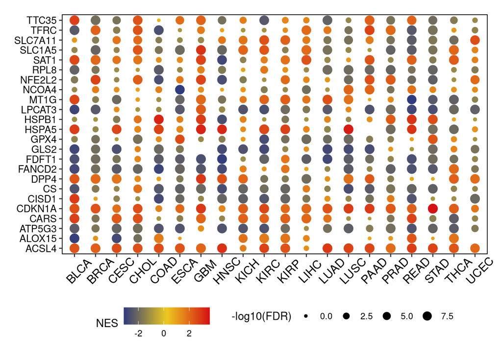

```r
# 设置感兴趣的通路
# Set pathway of interest
pathOfInterest <- "HALLMARK_EPITHELIAL_MESENCHYMAL_TRANSITION"

# 提取和该通路有关的NES
# Extract NES values related to this pathway
tmp <- gseaTab[which(gseaTab$term == pathOfInterest),]

# 颜色配置
# Color Configuration
my_palette <- colorRampPalette(c(darkblue,yellow,darkred), alpha=TRUE)(n=128)

# 气泡图绘制
# Bubble Plot Visualization
ggplot(tmp, aes(x=tumor,y=gene)) +
  geom_point(aes(size=-log10(FDR),color=NES)) +
  scale_color_gradientn('NES',
                        colors=my_palette) +
  scale_size_continuous(range = c(1,4)) +
  theme_bw() +
  theme(panel.grid.minor = element_blank(),
        panel.grid.major = element_blank(),
        axis.text.x = element_text(angle = 45, size = 12, hjust = 0.3, vjust = 0.5, color = "black"),
        axis.text.y = element_text(size = 10, color = "black"),
        axis.title = element_blank(),
        panel.border = element_rect(size = 0.7, linetype = "solid", colour = "black"),
        legend.position = "bottom",
        plot.margin = unit(c(1,1,1,1), "lines"))
```

```r
# 保存为PDF
# Save as PDF
ggsave(paste0("GSEA regarding ",pathOfInterest," in pancancer.pdf"), width = 8,height = 6)
```

# 会话信息